# GES 673 ESDA with Flesch Kincaid Index using Twitter

## Notice the observed rank of 500 meaning that zero simulated value was more extreme than the observed. What is the p-value here? What can you conclude about the two Moran's I between county and zip-code?

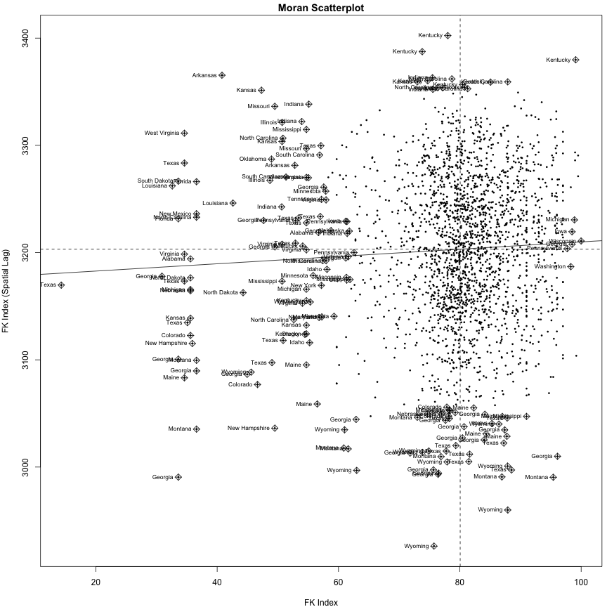

[output not shown]

[output cut: 117 more lines]

```
## West Virginia   0.06  -0.06  0.06    1.00_*  0.00   0.00_*
## West Virginia   0.18  -0.18  0.18_*  1.01_*  0.02   0.01_*
## Wisconsin      -0.01   0.01 -0.01    1.00_*  0.00   0.00
## Wisconsin       0.00   0.00  0.00    1.00_*  0.00   0.00
## Wisconsin       0.00   0.00  0.00    1.00_*  0.00   0.00_*
## Wyoming         0.04  -0.05 -0.08    0.99_*  0.00   0.00
## Wyoming         0.03  -0.03 -0.06    1.00_*  0.00   0.00
## Wyoming        -0.10   0.10 -0.11_*  1.00    0.01   0.00
## Wyoming        -0.04   0.03 -0.06    0.99_*  0.00   0.00
## Wyoming        -0.02   0.01 -0.06    0.99_*  0.00   0.00
## Wyoming        -0.05   0.04 -0.09_*  0.99_*  0.00   0.00
## Wyoming        -0.04   0.04 -0.07    0.99_*  0.00   0.00
## Wyoming         0.05  -0.06 -0.10_*  0.99_*  0.00   0.00
## Wyoming        -0.11   0.11 -0.12_*  1.00_*  0.01   0.00
## Wyoming        -0.11   0.11 -0.11_*  1.00_*  0.01   0.01_*
```

```r
par(mar = c(4, 4, 1.5, 0.5))
moran.plot(geocnty.fk@data$MEANflesch, listw = sw.cntyfk, zero.policy = T, pch = 16,
    col = "black", cex = 0.5, quiet = F, labels = as.character(geocnty.fk$STATE_NAME),
    xlab = "FK Index", ylab = "FK Index (Spatial Lag)", main = "Moran Scatterplot")
```

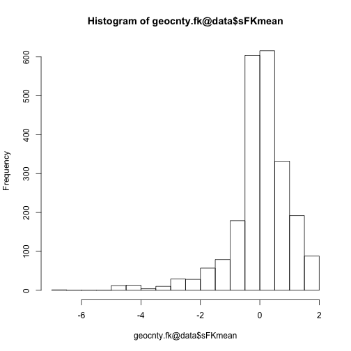

```r
# manually make a moran plot standarize variables save to a new column
geocnty.fk@data$sFKmean <- scale(geocnty.fk@data$MEANflesch)
hist(geocnty.fk@data$sFKmean)
```

```r
summary(geocnty.fk@data$sFKmean)
```

```
##        V1
##  Min.   :-6.588
##  1st Qu.:-0.344
##  Median : 0.066
##  Mean   : 0.000
##  3rd Qu.: 0.575
##  Max.   : 1.997
```

```r
summary(geocnty.fk@data$lag_sFKmean)
```

```
## Length  Class   Mode
##      0   NULL   NULL
```

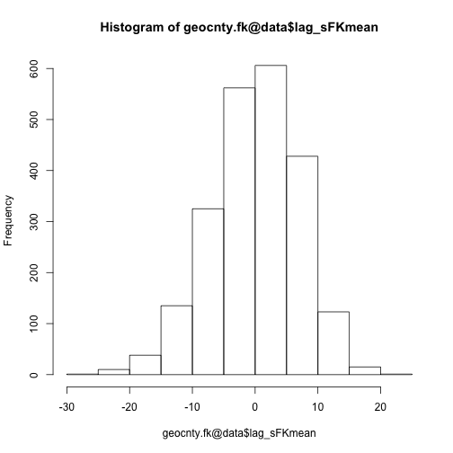

```r
# create a lagged variable
geocnty.fk@data$lag_sFKmean <- lag.listw(sw.cntyfk, geocnty.fk@data$sFKmean)
hist(geocnty.fk@data$lag_sFKmean)
```

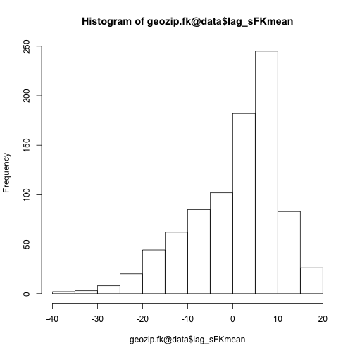

```r
# manually make a moran plot standarize variables save to a new column
geozip.fk@data$sFKmean <- scale(geozip.fk@data$MEANflesch)

# create a lagged variable
geozip.fk@data$lag_sFKmean <- lag.listw(sw.zipfk, geozip.fk@data$sFKmean)
hist(geozip.fk@data$lag_sFKmean)
```

```r
summary(geozip.fk@data$sFKmean)
```

```
##        V1
##  Min.   :-7.048
##  1st Qu.:-0.349
##  Median : 0.059
##  Mean   : 0.000
##  3rd Qu.: 0.474
##  Max.   : 3.901
```

```r
summary(geozip.fk@data$lag_sFKmean)
```

```
##        V1
##  Min.   :-39.86
##  1st Qu.: -5.39
##  Median :  3.03
##  Mean   :  0.58
##  3rd Qu.:  7.50
##  Max.   : 19.77
```

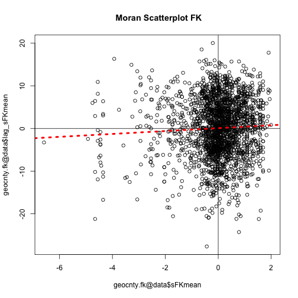

```r
plot(x = geocnty.fk@data$sFKmean, y = geocnty.fk@data$lag_sFKmean, main = " Moran Scatterplot FK")
abline(h = 0, v = 0)
abline(lm(geocnty.fk@data$lag_sFKmean ~ geocnty.fk@data$sFKmean), lty = 3, lwd = 4,
    col = "red")
```

```r
# check out the outliers click on one or two and then hit escape (or click
# finish) identify(geocnty.fk$sFKmean, geocnty.fk$lag_sFKmean,
# geocnty.fk$STATE_NAME, cex = 0.8)
```

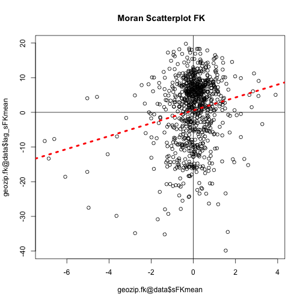

```r
plot(x = geozip.fk@data$sFKmean, y = geozip.fk@data$lag_sFKmean, main = " Moran Scatterplot FK")
abline(h = 0, v = 0)
abline(lm(geozip.fk@data$lag_sFKmean ~ geozip.fk@data$sFKmean), lty = 3, lwd = 4,
    col = "red")
```

```r
# check out the outliers click on one or two and then hit escape (or click
# finish) identify(geozip.fk$sFKmean, geozip.fk$lag_sFKmean,
# geozip.fk$STATE, cex = 0.8)
```

## Notice that the relationship is stronger at the zip-code level. Why do you think this is the case? Is it larger enough to alter our research question or interpretation of the results?

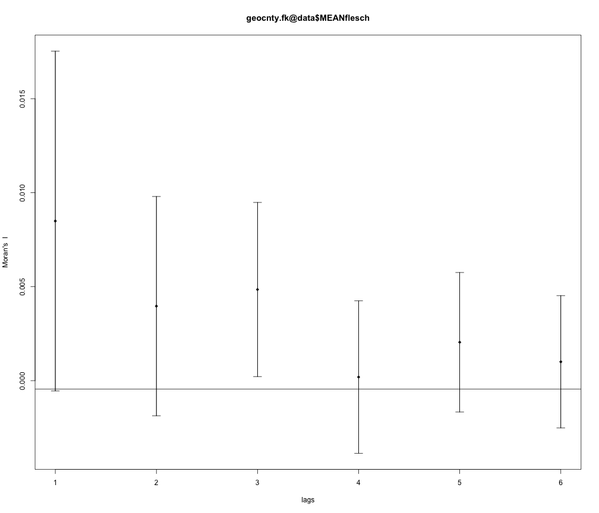

```r
plot(sp.correlogram(neighbours = nb.cntyfk, var = geocnty.fk@data$MEANflesch,
    order = 6, method = "I", style = "B", zero.policy = TRUE))
```

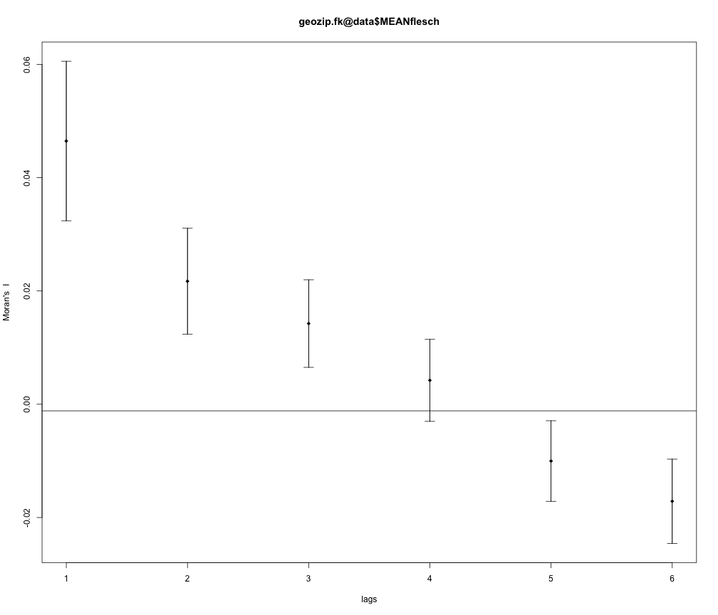

```r
plot(sp.correlogram(neighbours = nb.zipfk, var = geozip.fk@data$MEANflesch,
    order = 6, method = "I", style = "B", zero.policy = TRUE))
```

## What is the best interpretation of the correlogram for each - county and zip-code? Do you think an analysis for zip-code is best (hint: error bars)?

```r
local_cnty.mi <- localmoran(x = geocnty.fk@data$MEANflesch, listw = sw.cntyfk)
# p.adjust.method is appropriate for big data due to multiple hypothesis
# testing

local_zip.mi <- localmoran(x = geozip.fk@data$MEANflesch, listw = sw.zipfk)
# p.adjust.method is appropriate for big data due to multiple hypothesis
# testing
```

```r
class(local_cnty.mi)
```

```
## [1] "localmoran" "matrix"
```

```r
colnames(local_cnty.mi)
```

```
## [1] "Ii"        "E.Ii"      "Var.Ii"    "Z.Ii"      "Pr(z > 0)"
```

```r
class(local_zip.mi)
```

```
## [1] "localmoran" "matrix"
```

```r
colnames(local_zip.mi)
```

```
## [1] "Ii"        "E.Ii"      "Var.Ii"    "Z.Ii"      "Pr(z > 0)"
```

```r
# summary stats Moran's I for both county and 3-digit zip code
summary(local_cnty.mi)
```

```
##        Ii              E.Ii             Var.Ii          Z.Ii
##  Min.   :-64.22   Min.   :-0.0178   Min.   :39.9   Min.   :-10.166
##  1st Qu.: -1.56   1st Qu.:-0.0178   1st Qu.:39.9   1st Qu.: -0.245
##  Median :  0.07   Median :-0.0178   Median :39.9   Median :  0.014
##  Mean   :  0.34   Mean   :-0.0178   Mean   :39.9   Mean   :  0.057
##  3rd Qu.:  1.99   3rd Qu.:-0.0178   3rd Qu.:39.9   3rd Qu.:  0.318
##  Max.   : 98.81   Max.   :-0.0178   Max.   :39.9   Max.   : 15.648
##    Pr(z > 0)
##  Min.   :0.000
##  1st Qu.:0.375
##  Median :0.494
##  Mean   :0.489
##  3rd Qu.:0.597
##  Max.   :1.000
```

```r
summary(local_zip.mi)
```

```
##        Ii              E.Ii             Var.Ii          Z.Ii
##  Min.   :-61.28   Min.   :-0.0465   Min.   :39.4   Min.   :-9.756
##  1st Qu.: -1.47   1st Qu.:-0.0465   1st Qu.:39.4   1st Qu.:-0.227
##  Median :  0.49   Median :-0.0465   Median :39.4   Median : 0.085
##  Mean   :  1.86   Mean   :-0.0465   Mean   :39.4   Mean   : 0.303
##  3rd Qu.:  3.30   3rd Qu.:-0.0465   3rd Qu.:39.4   3rd Qu.: 0.534
##  Max.   :136.79   Max.   :-0.0465   Max.   :39.4   Max.   :21.801
##    Pr(z > 0)
##  Min.   :0.000
##  1st Qu.:0.297
##  Median :0.466
##  Mean   :0.453
##  3rd Qu.:0.590
##  Max.   :1.000
```

## What can you determine from five number summary of Ii for both county and zipcode?

```r
geocnty.fk$lmi <- local_cnty.mi[, 1]
geocnty.fk$lmi
```

[output not shown]

[output cut: 359 more lines]

```r
geocnty.fk$lmi.p <- local_cnty.mi[, 5]
summary(geocnty.fk$lmi.p)
```

```
##    Min. 1st Qu.  Median    Mean 3rd Qu.    Max.
##   0.000   0.375   0.494   0.489   0.597   1.000
```

```r
summary(geocnty.fk$lmi)
```

```
##    Min. 1st Qu.  Median    Mean 3rd Qu.    Max.
##  -64.20   -1.56    0.07    0.34    1.99   98.80
```

```r
summary(geocnty.fk$lmi.p)
```

```
##    Min. 1st Qu.  Median    Mean 3rd Qu.    Max.
##   0.000   0.375   0.494   0.489   0.597   1.000
```

```r
# do we expect the p-value range from 0 to 1?
geozip.fk$lmi <- local_zip.mi[, 1]
geozip.fk$lmi.p <- local_zip.mi[, 5]
summary(geozip.fk$lmi)
```

```
##    Min. 1st Qu.  Median    Mean 3rd Qu.    Max.
##  -61.30   -1.47    0.49    1.86    3.30  137.00
```

```r
summary(geozip.fk$lmi.p)
```

```
##    Min. 1st Qu.  Median    Mean 3rd Qu.    Max.
##   0.000   0.297   0.466   0.452   0.590   1.000
```

```r
geocnty.fk@data$lmi.p.sig <- as.factor(ifelse(local_cnty.mi[, 5] < 0.001, "Sig p<.001",
    ifelse(local_cnty.mi[, 5] < 0.05, "Sig p<.05", "NS")))
##
geozip.fk@data$lmi.p.sig <- as.factor(ifelse(local_zip.mi[, 5] < 0.001, "Sig p<.001",
    ifelse(local_zip.mi[, 5] < 0.05, "Sig p<.05", "NS")))
```

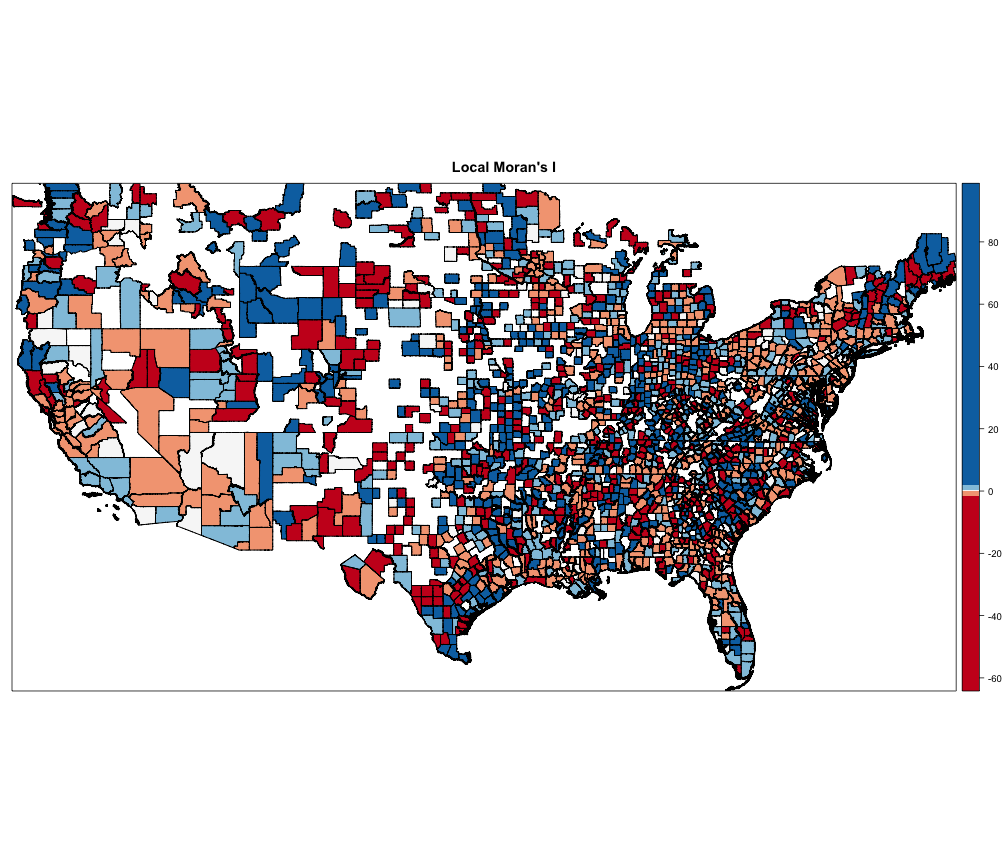

```r
spplot(geocnty.fk, "lmi", at = summary(geocnty.fk$lmi), col.regions = brewer.pal(5,
    "RdBu"), main = "Local Moran's I")
```

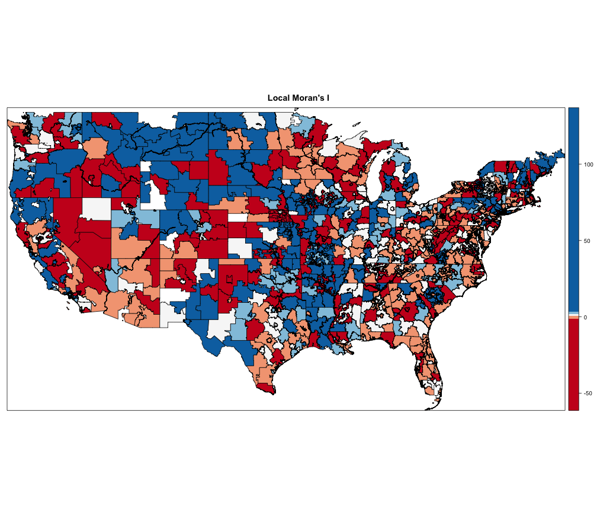

```r
##
spplot(geozip.fk, "lmi", at = summary(geozip.fk$lmi), col.regions = brewer.pal(5,
    "RdBu"), main = "Local Moran's I")
```

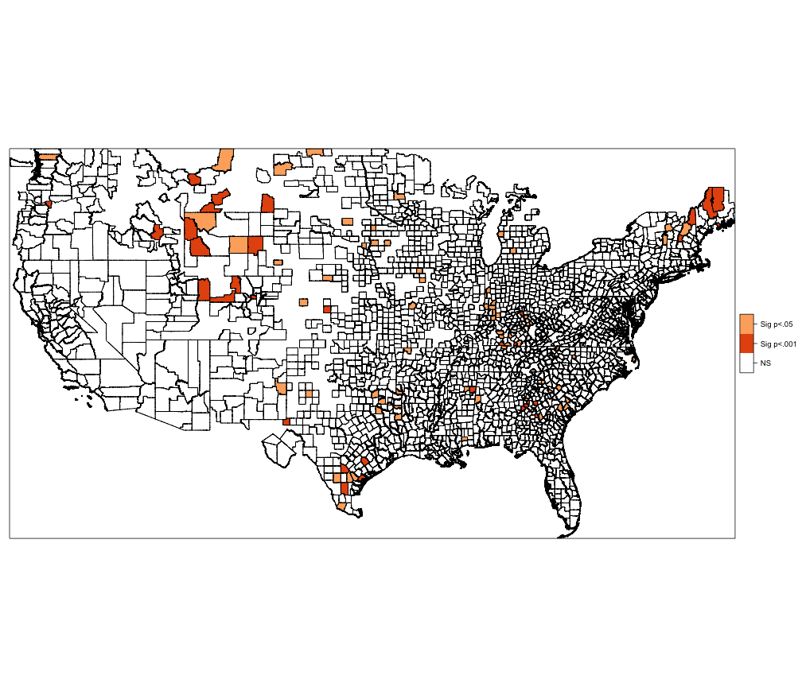

```r
spplot(geocnty.fk, "lmi.p.sig", col.regions = c("white", "#E6550D", "#FDAE6B"))
```

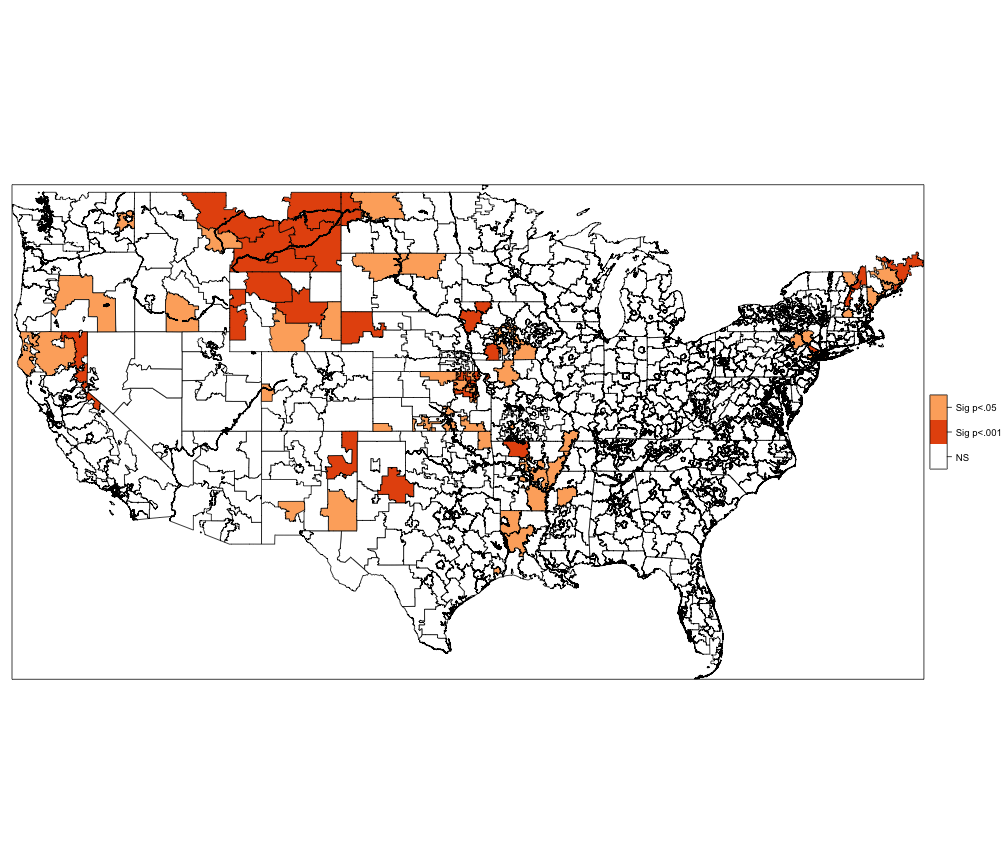

```r
##
spplot(geozip.fk, "lmi.p.sig", col.regions = c("white", "#E6550D", "#FDAE6B"))
```

```r
# identify the moran plot quadrant for each observation
geocnty.fk@data$quad_sig <- NA
geocnty.fk@data[(geocnty.fk$sFKmean > 0 & geocnty.fk$lag_sFKmean > 0) & (local_cnty.mi[,
    5] <= 0.05), "quad_sig"] <- 1
geocnty.fk@data[(geocnty.fk$sFKmean < 0 & geocnty.fk$lag_sFKmean > 0) & (local_cnty.mi[,
    5] <= 0.05), "quad_sig"] <- 2
geocnty.fk@data[(geocnty.fk$sFKmean < 0 & geocnty.fk$lag_sFKmean > 0) & (local_cnty.mi[,
    5] <= 0.05), "quad_sig"] <- 3
geocnty.fk@data[(geocnty.fk$sFKmean > 0 & geocnty.fk$lag_sFKmean < 0) & (local_cnty.mi[,
    5] <= 0.05), "quad_sig"] <- 4
geocnty.fk@data[(local_cnty.mi[, 5] > 0.05), "quad_sig"] <- 5

summary(geocnty.fk@data$quad_sig)
```

```
##    Min. 1st Qu.  Median    Mean 3rd Qu.    Max.    NA's
##    1.00    5.00    5.00    4.92    5.00    5.00      63
```

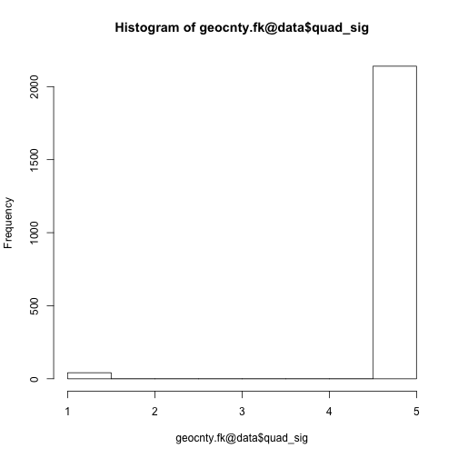

```r
hist(geocnty.fk@data$quad_sig)
```

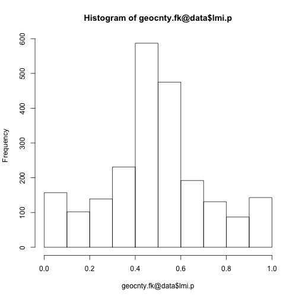

```r
hist(geocnty.fk@data$lmi.p)
```

```r
# identify the moran plot quadrant for each observation
geozip.fk@data$quad_sig <- NA
geozip.fk@data[(geozip.fk$sFKmean > 0 & geozip.fk$lag_sFKmean > 0) & (local_zip.mi[,
    5] <= 0.05), "quad_sig"] <- 1
geozip.fk@data[(geozip.fk$sFKmean < 0 & geozip.fk$lag_sFKmean > 0) & (local_zip.mi[,
    5] <= 0.05), "quad_sig"] <- 2
geozip.fk@data[(geozip.fk$sFKmean < 0 & geozip.fk$lag_sFKmean > 0) & (local_zip.mi[,
    5] <= 0.05), "quad_sig"] <- 3
geozip.fk@data[(geozip.fk$sFKmean > 0 & geozip.fk$lag_sFKmean < 0) & (local_zip.mi[,
    5] <= 0.05), "quad_sig"] <- 4
geozip.fk@data[(local_zip.mi[, 5] > 0.05), "quad_sig"] <- 5

summary(geozip.fk@data$quad_sig)
```

```
##    Min. 1st Qu.  Median    Mean 3rd Qu.    Max.    NA's
##    1.00    5.00    5.00    4.85    5.00    5.00      50
```

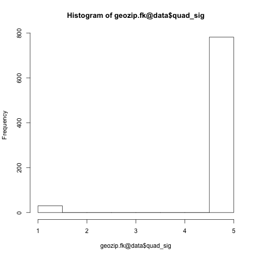

```r
hist(geozip.fk@data$quad_sig)
```

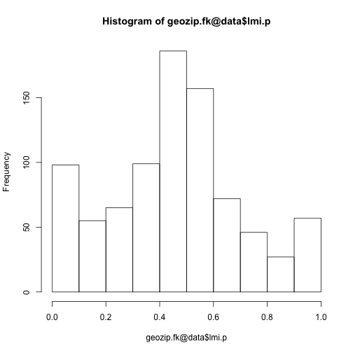

```r
hist(geozip.fk@data$lmi.p)
```

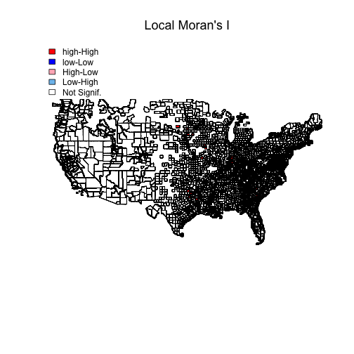

[figure not shown]

```r
# Set the breaks for the thematic map classes
breaks <- seq(1, 5, 1)

# Set the corresponding labels for the thematic map classes
labels <- c("high-High", "low-Low", "High-Low", "Low-High", "Not Signif.")

# see ?findInterval - This is necessary for making a map
np <- findInterval(geocnty.fk$quad_sig, breaks)

# Assign colors to each map class
colors <- c("red", "blue", "lightpink", "skyblue2", "white")
# colors[np] manually sets the color for each county
plot(geocnty.fk, col = colors[np])
mtext("Local Moran's I", cex = 1.5, side = 3, line = 1)
legend("topleft", legend = labels, fill = colors, bty = "n")
```

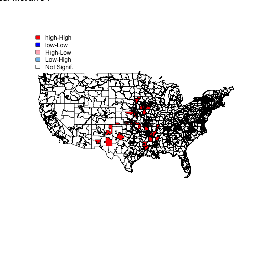

[figure not shown]

```r
# Set the breaks for the thematic map classes
breaks2 <- seq(1, 5, 1)

# Set the corresponding labels for the thematic map classes
labels2 <- c("high-High", "low-Low", "High-Low", "Low-High", "Not Signif.")

# see ?findInterval - This is necessary for making a map
np2 <- findInterval(geozip.fk$quad_sig, breaks2)

# Assign colors to each map class
colors2 <- c("red", "blue", "lightpink", "skyblue2", "white")
# colors[np] manually sets the color for each county
plot(geozip.fk, col = colors2[np2])
mtext("Local Moran's I", cex = 1.5, side = 20, line = 1)
legend("topleft", legend = labels, fill = colors, bty = "n")
```